# Midterm Project

##### 3. If we consider the number of wounded and killed combined to be of primary interest, explore the relationships of population size and the three poverty variables to this combined count. Label the most interesting data point in one of the graphs with the group name (gname) that committed the incident.

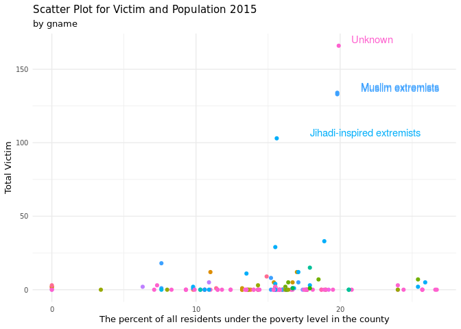

```r
finalmerge %>%
  select(nkill,nwound,POPESTIMATE2013, POPESTIMATE2014,POPESTIMATE2015,POPESTIMATE2016, PCTPOVALL_2015, PCTPOV017_2015,MEDHHINC_2015, gname) %>%
mutate(total_incident = ( finalmerge$nkill + finalmerge$nwound))%>%
mutate_if(is.numeric , replace_na, replace = 0) -> percent_count

ggplot(percent_count, aes(PCTPOVALL_2015,total_incident, colour = gname)) + geom_point()+  geom_text(aes(label=ifelse(total_incident> 50,as.character(gname),'')),hjust=-0.3,vjust=-0.3)+  theme_classic() + labs(title = "Scatter Plot for Victim and Population 2015", subtitle = "by gname", x = "The percent of all residents under the poverty level in the county", y = "Total Victim") +scale_fill_discrete(name = "Weapon Type Text")+theme_minimal()  + theme(panel.border = element_blank(), text=element_text(size=9.5, family="Arial light"))+ theme(legend.position='none')
```

The scatter plot shows, `Unknown`, `Muslim Extremist` and `Jihadi-inspired extremists` have the highest count for the attack

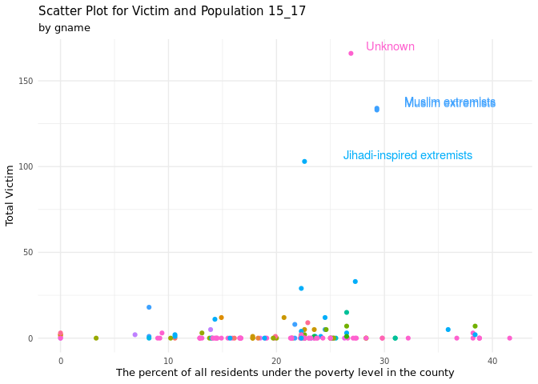

```r
ggplot(percent_count, aes(PCTPOV017_2015,total_incident, colour = gname)) + geom_point()+  geom_text(aes(label=ifelse(total_incident> 50,as.character(gname),'')),hjust=-0.3,vjust=-0.3)+  theme_classic() + labs(title = "Scatter Plot for Victim and Population 15_17", subtitle = "by gname", x ="The percent of all residents under the poverty level in the county", y = "Total Victim") +scale_fill_discrete(name = "Weapon Type Text")+theme_minimal()  + theme(panel.border = element_blank(), text=element_text(size=9.5, family="Arial light"))+ theme(legend.position='none')
```

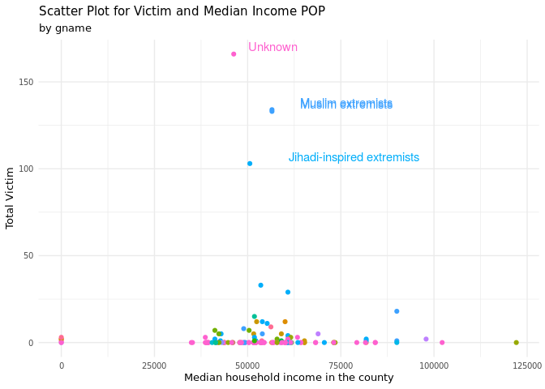

```r
ggplot(percent_count, aes(MEDHHINC_2015,total_incident, colour = gname)) + geom_point()+  geom_text(aes(label=ifelse(total_incident> 50,as.character(gname),'')),hjust=-0.3,vjust=-0.3)+  theme_classic() + labs(title = "Scatter Plot for Victim and Median Income POP", subtitle = "by gname", x = "Median household income in the county", y = "Total Victim") +scale_fill_discrete(name = "Weapon Type Text")+theme_minimal()  + theme(panel.border = element_blank(), text=element_text(size=9.5, family="Arial light"))+ theme(legend.position='none')
```

> Here, we can see that gname with Unknown followed by Muslim Extremists are the group that has occured highest victims through out the Poverty datasets.

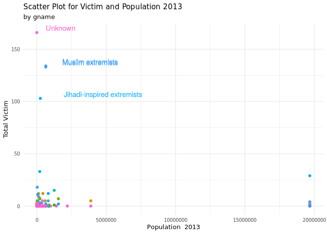

```r
ggplot(percent_count, aes((POPESTIMATE2013),total_incident, colour = gname)) + geom_point()+  geom_text(aes(label=ifelse(total_incident> 50,as.character(gname),'')),hjust=-0.3,vjust=-0.3)+  theme_classic() + labs(title = "Scatter Plot for Victim and Population 2013", subtitle = "by gname", x = "Population  2013", y = "Total Victim") +scale_fill_discrete(name = "Weapon Type Text")+theme_minimal()  + theme(panel.border = element_blank(), text=element_text(size=9.5, family="Arial light"))+ theme(legend.position='none')
```

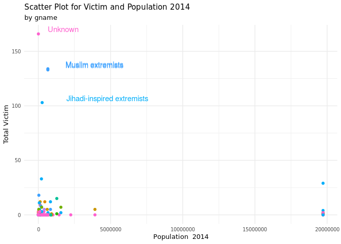

```r
ggplot(percent_count, aes((POPESTIMATE2014),total_incident, colour = gname)) + geom_point()+  geom_text(aes(label=ifelse(total_incident> 50,as.character(gname),'')),hjust=-0.3,vjust=-0.3)+  theme_classic() + labs(title = "Scatter Plot for Victim and Population 2014", subtitle = "by gname", x = "Population  2014", y = "Total Victim") +scale_fill_discrete(name = "Weapon Type Text")+theme_minimal()  + theme(panel.border = element_blank(), text=element_text(size=9.5, family="Arial light"))+ theme(legend.position='none')
```

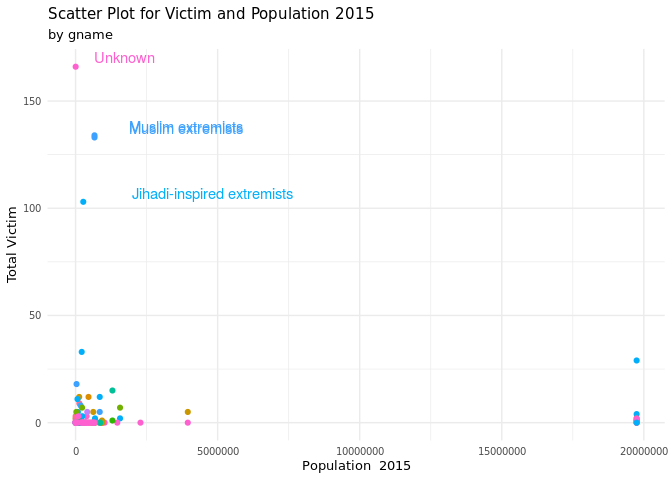

```r
ggplot(percent_count, aes((POPESTIMATE2015),total_incident, colour = gname)) + geom_point()+  geom_text(aes(label=ifelse(total_incident> 50,as.character(gname),'')),hjust=-0.3,vjust=-0.3)+  theme_classic() + labs(title = "Scatter Plot for Victim and Population 2015", subtitle = "by gname", x = "Population  2015", y = "Total Victim") +scale_fill_discrete(name = "Weapon Type Text")+theme_minimal()  + theme(panel.border = element_blank(), text=element_text(size=9.5, family="Arial light"))+ theme(legend.position='none')
```

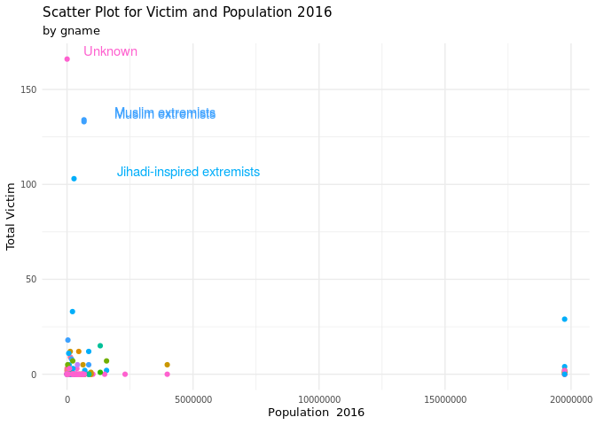

```r
ggplot(percent_count, aes((POPESTIMATE2016),total_incident, colour = gname)) + geom_point()+  geom_text(aes(label=ifelse(total_incident> 50,as.character(gname),'')),hjust=-0.3,vjust=-0.3)+  theme_classic() + labs(title = "Scatter Plot for Victim and Population 2016", subtitle = "by gname", x = "Population  2016", y = "Total Victim") +scale_fill_discrete(name = "Weapon Type Text")+theme_minimal()  + theme(panel.border = element_blank(), text=element_text(size=9.5, family="Arial light"))+ theme(legend.position='none')
```

> Not all Gname is shown in the scatter plot. The label are hidden in order to focus the top interesting data point in group name (gname) that committed the incident.